# Model-based post-stratification: UK2015 (second go)

by Laci

Wednesday, August 24, 2016

# Summary

The script & first results of our GE2015 prediction project.

The aim is to test how data collected through Voting Advice Applications perform in ‘predicting’ vote shares while implementing a model-based solution to post-stratification, such as [Wang et. al., 2014](http://www.stat.columbia.edu/~gelman/research/published/forecasting-with-nonrepresentative-polls.pdf) and [Kastellec et. al., 2014](http://www.princeton.edu/~jkastell/MRP_primer/mrp_primer.pdf).

In this example, we take the data from the VAA designed for the UK 2015 general elections. We are looking at two data sets: the ‘large VAA’ contains basic demographic and probability to vote (ptv) data, the smaller ‘popup’ data set contains classic survey measures of political interest, vote intention, and 2010 vote recall as well.

In the large VAA, we are looking at highest expressed probability to vote (ptv) as dependent variable. In the popup data, our dependent variable is vote intention. In our random effects models, we regress these on the post-stratifying variables of age, gender, and education, as well as political interest, party identification, and 2010 vote in the popup sample. This data set does not yet contain geographic information beyond the country level (this will not be a problem in the Brexit data set).

After fitting the model, we generated predictions at all combinations of these variables (post-stratification cells) that are present in the 2010 British Election Study post-election wave (excluding non-voters). The model itself is able to generate predictions at post-stratification cells even if they are not themselves present in the VAA data (by simply combining the intercept and the random effects), which we found as major advantage to non model-based solutions.

The weighted predictions are the sum of the cell-level probabilities multiplied by those cells’ population in the BES2010. We are yet to figure out how to account for the fact that the BES cell proportions are estimates themselves, to include their variability in our analysis.

### Preview results

To view the plot code scroll down to the ‘Results’ section, this is just a copy of the image.

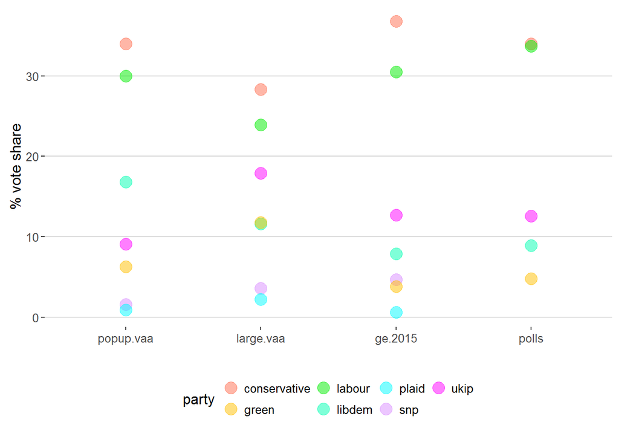

# Why are we doing this?

Papers like the two linked above give an idea of non-representative polling and what additional information is needed to use them. We want to contribute by:

- exploring the proper use of probability samples for weighting non-representative polls. If the source of bias of non-representative surveys was only demographics, such as age or gender, we could use known population totals as golden standards from the latest available census. However, these surveys are often biased on non-demographic variables like partisanship. Therefore, we need to rely on probability samples where instead of population totals, we find an estimate. None of the papers above demonstrated use of the variability of the probability sample estimates.
- demonstrating model-based post-stratification on multiple cases and election contexts, rather than fitting a single model to a unique case, for the sake of a more general argument. We are working with Voting Advice Applications fielded by the same developers, with comparable survey questions and modes of distribution, which have been running for 10 years in 39 countries. We will implement our method on two UK data sets (2015 General Elections and 2016 Brexit referendum), and a 28-sample pan-Eureopan VAA designed for the 2014 EU Parliamentary Elections.

# BES2010

Description and preparation of BES2010 data for post-stratification.

We are using the 2010 BES post-election wave as golden standard to post-stratify the VAA sample, that is, to use the number of observations in the BES’ post-stratification cells (e.g. young, female not highly educated, politically not interested Conservative voters) as targets for weighting.

The BES2010 is a weighted data set, data set documentation is available [here](http://www.britishelectionstudy.com/custom/uploads/2014/04/2010BESTechnicalReport.pdf).

Given the number of observations in this data set (888.93 is the weighted sum of observations, after exclusision of non-voters and missing data), sparse cell population estimates are unstable. Additionally, some cells may be completely missed by the BES survey.

To prepare the cross-tabulated, weighted sample for post-stratification, we define a survey design object using the [`survey` package](https://cran.r-project.org/web/packages/survey/survey.pdf) and generate cell-level estimates (of cell totals) with their standard errors, as follows:

```r
# BES data management ---------------
setwd("C:/db_export/UK 2015")
library(foreign)
library(data.table)

bes <- data.table(read.csv("bes.2010.post.varselect1.csv"))  ## this contains the relevant variables I selected see below. filtered post-election respondents only, they have a sep. weight variable!
names(bes) <- c("pint", "pid0", "pid", "turnout0", "vote", "female",
    "age", "edu", "postw")  ##turnout==1 if recalled voting. postw is the weight variable.

# recoding variables.
bes$pid[bes$pid0 == 2] <- 99  ## pid0 is asking whether they identify with a party at all, while pid asks for the party

bes <- bes[, c(1, 3:9), with = FALSE]

bes$pint[bes$pint == -1] <- NA
bes$pint[bes$pint <= 3] <- 1
bes$pint[bes$pint > 3] <- 0
bes$pint <- factor(bes$pint)

bes$vote[bes$vote < 1] <- NA
bes$vote <- factor(bes$vote)
levels(bes$vote) <- c("l", "c", "li", "snp", "pc", "g", "ukip",
    "bnp", "other")
bes$vote[bes$vote == "bnp"] <- "other"
bes$vote <- factor(bes$vote)
levels(bes$vote) <- c(levels(bes$vote), "none")
bes$vote[bes$turnout0 == 2] <- "none"
bes$vote.rec <- bes$vote
bes$vote.rec[bes$vote.rec == "snp"] <- "other"
bes$vote.rec[bes$vote.rec == "pc"] <- "other"
bes$vote.rec[bes$vote.rec == "g"] <- "other"
bes$vote.rec <- factor(bes$vote.rec)  ## resulting variable puts snp and pc votes into others. We have very very small post-stratification cells, wanted to have broad categories.

bes$pid[bes$pid == 1] <- "l"
bes$pid[bes$pid == 2] <- "c"
bes$pid[bes$pid == 3] <- "li"
bes$pid[bes$pid == 7] <- "ukip"
bes$pid[bes$pid == 99] <- "none"
bes$pid[bes$pid >= 4 & bes$pid <= 6] <- "other"
bes$pid[bes$pid >= 8 & bes$pid <= 9] <- "other"
bes$pid <- factor(bes$pid)

bes$age[bes$age == -2] <- NA
bes$age[bes$age == -1] <- NA
bes$age.c[bes$age >= 18 & bes$age <= 24] <- "1"
bes$age.c[bes$age >= 25 & bes$age <= 34] <- "2"
bes$age.c[bes$age >= 35 & bes$age <= 44] <- "3"
bes$age.c[bes$age >= 45 & bes$age <= 54] <- "4"
bes$age.c[bes$age >= 55 & bes$age <= 64] <- "5"
bes$age.c[bes$age >= 65 & bes$age <= 106] <- "6"
bes$age.c <- factor(bes$age.c)

bes$edu[bes$edu == -2] <- NA
bes$edu[bes$edu == -1] <- NA
bes$uni <- 0
bes$uni[is.na(bes$edu)] <- NA
bes$uni[bes$edu <= 3] <- 1
bes$uni <- factor(bes$uni)  ## resulting dummy variable indicates university education. We have very very small post-stratification cells, wanted to have broader categories.

bes$female <- bes$female - 1
bes$female <- factor(bes$female)

# post-stratification cell estimates and standard errors FOR POPUP SAMPLE.

library(survey)  ## for proper analysis with weights. Alternatively we just sum up the weights per post-stratification cells, which I've done previously, however, we would not have standard errors then.

s.bes <- svydesign(ids = ~0, variables = ~female + age.c + uni +
    pint + pid + vote.rec + turnout0, weights = ~postw, data = bes)  ##defines survey design object see ?svydesign
s.bes <- subset(s.bes, turnout0 == 1 & vote.rec != "none")  ## I'm subsetting so that only voters remain in the data set. I'm doing this within the survey design object, and not previously, and leave it to the package to figure out what this means for the remaining weights.

bes.total <- svytotal(~interaction(female, age.c, uni, pint,
    pid, vote.rec), s.bes, na.rm = TRUE)  ##crosstabulates and estimates proportions. the rest deals with it's output: to get a working data frame out of it.
bes.pop <- as.data.frame(bes.total)
bes.pop$cell <- rownames(bes.pop)  ## it's a long character string. we need the actual variable values out of it.
bes.pop <- as.data.table(bes.pop)
bes.pop <- bes.pop[total != 0, c(3, 1, 2), with = FALSE]  ##remember order is female, age.c, uni, pint, pid, vote.rec (will have to define below)

s <- unlist(strsplit(bes.pop$cell, "[)]"))  ## we need every second element (even numbers), the rest is junk
n <- length(s)
ss <- s[seq(2, n, 2)]
bes.pop$cell <- ss  ## I'm adding this as a single post-stratification cell identifyier, may be useful for later.
sss <- unlist(strsplit(ss, "[.]"))
elems <- unlist(strsplit(sss, "\\."))
m <- matrix(elems, ncol = 6, byrow = TRUE)
m <- as.data.frame(m)  ## re-created the original variables
bes.pop <- cbind(bes.pop, m)
names(bes.pop) <- c("cell", "total", "SE", "female", "age.c",
    "uni", "pint", "pid", "vote.rec")

bes.pop[, `:=`(female, as.factor(female))]
bes.pop[, `:=`(age.c, as.factor(age.c))]
bes.pop[, `:=`(uni, as.factor(uni))]
bes.pop[, `:=`(pint, as.factor(pint))]
bes.pop[, `:=`(pid, as.factor(pid))]
bes.pop[, `:=`(vote.rec, as.factor(vote.rec))]

bes.pop$pct <- bes.pop$total/sum(bes.pop$total)  ##we need percentages for weighting later. they add up to 1.
bes.pop <- bes.pop[order(female, age.c, uni, pint, pid, vote.rec)]

# post-stratification cell estimates and standard errors FOR LARGE VAA
library(survey)  #everything as above. added to objects '1' (bes.pop1) to indicate it is for the first models

s.bes1 <- svydesign(ids = ~0, variables = ~turnout0 + female +
    age.c + uni + vote.rec, weights = ~postw, data = bes)
s.bes1 <- subset(s.bes1, turnout0 == 1 & vote.rec != "none")  ##excluded non-voters

bes.total1 <- svytotal(~interaction(female, age.c, uni), s.bes1,
    na.rm = TRUE)
bes.pop1 <- as.data.frame(bes.total1)
bes.pop1$cell <- rownames(bes.pop1)
bes.pop1 <- as.data.table(bes.pop1)  #order is female, age.c, uni

s1 <- unlist(strsplit(bes.pop1$cell, "[)]"))
n1 <- length(s1)
ss1 <- s1[seq(2, n1, 2)]
bes.pop1$cell <- ss1
sss1 <- unlist(strsplit(ss1, "[.]"))
elems1 <- unlist(strsplit(sss1, "\\."))
m1 <- matrix(elems1, ncol = 3, byrow = TRUE)
m1 <- as.data.frame(m1)  ## re-created the original variables
bes.pop1 <- cbind(bes.pop1, m1)
names(bes.pop1) <- c("total", "SE", "cell", "female", "age.c",
    "uni")

bes.pop1[, `:=`(female, as.factor(female))]
bes.pop1[, `:=`(age.c, as.factor(age.c))]
bes.pop1[, `:=`(uni, as.factor(uni))]

bes.pop1$pct <- bes.pop1$total/sum(bes.pop1$total)
bes.pop1 <- bes.pop1[order(female, age.c, uni)]

rm("bes.total1", "elems1", "m1", "n1", "s1", "ss1", "sss1", "bes.total",
    "elems", "m", "n", "s", "ss", "sss")  #cleaning up workspace
bes.pop
```

```
##                     cell      total        SE female age.c uni pint   pid vote.rec          pct
##   1:         0.1.0.0.c.c  2.9462944 2.9462944      0     1   0    0     c        c 0.0033144417
##   2:     0.1.0.0.c.other  0.8086233 0.8086233      0     1   0    0     c    other 0.0009096629
##   3:      0.1.0.0.none.l  0.8809427 0.8809427      0     1   0    0  none        l 0.0009910188
##   4:      0.1.0.0.ukip.l  3.8565867 3.8565867      0     1   0    0  ukip        l 0.0043384773
##   5:         0.1.0.1.c.c 14.3932176 7.3001834      0     1   0    1     c        c 0.0161916879
##  ---
## 293:        1.6.1.1.c.li  1.6367023 1.4578216      1     6   1    1     c       li 0.0018412125
## 294:         1.6.1.1.l.l  2.8214738 2.2873491      1     6   1    1     l        l 0.0031740243
## 295:       1.6.1.1.li.li  2.2414285 1.6683983      1     6   1    1    li       li 0.0025215009
## 296:     1.6.1.1.none.li  1.7514460 1.7514460      1     6   1    1  none       li 0.0019702938
## 297: 1.6.1.1.other.other  0.3827504 0.3827504      1     6   1    1 other    other 0.0004305761
```

A cell total below 2-3 indicates there may be only one observation in that particular combination of the post-stratifying variables. Their standard errors are equal to the estimates. Standard errors become smaller at more populous post-stratification cells, e.g.

```r
tail(bes.pop[order(total)],n=5)
```

```
##           cell    total       SE female age.c uni pint pid vote.rec        pct
## 1: 0.4.0.1.c.c 16.56929 4.772795      0     4   0    1   c        c 0.01863967
## 2: 0.6.0.1.c.c 16.60023 3.721532      0     6   0    1   c        c 0.01867447
## 3: 0.2.1.1.l.l 16.90194 5.638012      0     2   1    1   l        l 0.01901388
## 4: 0.5.0.1.c.c 16.99191 4.507571      0     5   0    1   c        c 0.01911510
## 5: 1.6.0.1.c.c 27.39875 5.906816      1     6   0    1   c        c 0.03082230
```

Thus accounting for variability at the particular post-stratification cell level may not be the best way to go. With `survey` we are able to estimate standard errors at the marginals, e.g.

```r
 svytotal(~interaction(female,uni),s.bes,na.rm=TRUE)
```

```
##                              total     SE
## interaction(female, uni)0.0 294.17 24.401
## interaction(female, uni)1.0 288.02 20.487
## interaction(female, uni)0.1 169.43 15.900
## interaction(female, uni)1.1 145.72 15.194
```

which may be better prior information for the models to follow?

Some additional info about the BES2010:

- the distribution of vote recall is about correct as per the eventual party vote shares (of 2010), except that it overestimates the Labour vote share by 4.7 per cent.

```r
svymean(~vote.rec,s.bes)
```

```
##                   mean     SE
## vote.recl     0.337327 0.0198
## vote.recc     0.367423 0.0191
## vote.recli    0.213278 0.0160
## vote.recukip  0.021502 0.0057
## vote.recother 0.060469 0.0076
## vote.recnone  0.000000 0.0000
```

- (here we can show BES vs. census marginals but it should be reasonable as it’s a weighted data set.)

# Predictions

The first bunch of code deals with the data preparation for both samples, including the construction of the dependent variable for the large VAA.

```r
# VAA data management ---------------
setwd("C:/db_export/UK 2015")
library(foreign)
library(data.table)

uk_full <- data.table(read.csv("UK.2015.csv"))
names(uk_full)[1] <- "token"
uk <- uk_full[country=="United Kingdom",c(1,18:23,55:61,77:79,81,83),with=FALSE] ## variable selection step, see below
rm(uk_full)
uk <- uk[order(token)]

uk$b.y. <- uk$background_question_3
uk$b.y.[is.na(uk$b.y.)] <- uk$background_question_6_is_mobile[is.na(uk$b.y.)]
uk$age <- 2015-(2002-uk$b.y.)

uk$female <- factor(uk$background_question_4)
uk$female[is.na(uk$female)] <- factor(uk$background_question_5_is_mobile)[is.na(uk$female)]

uk$edu <- factor(uk$background_question_2)
uk$edu[is.na(uk$edu)] <- factor(uk$background_question_7_is_mobile)[is.na(uk$edu)]
uk$edu[uk$edu=="0"] <- NA
uk$edu <- factor(uk$edu)

uk <- uk[,-c(2:7),with=FALSE]
names(uk)[2:13] <- c("ptv.pc","ptv.g","ptv.snp","ptv.ukip","ptv.li","ptv.l","ptv.c","pint","vote.int","vote.rec","pid","leftright")

select <- c("ptv.pc","ptv.g","ptv.snp","ptv.ukip","ptv.li","ptv.l","ptv.c")
uk[, select] <- lapply(uk[,select,with=FALSE],function(x)ifelse(x>=11,NA,x))

uk$turnout0[uk$vote.int==8] <- 0
uk$turnout0[uk$vote.int<8] <- 1 ## simplified turnout variable if needed.

uk$uni <- "0"
levels(uk$uni) <- c("0","1")
uk$uni[uk$edu=="5"] <- "1"
uk$uni[uk$edu=="6"] <- "1"
uk$uni[is.na(uk$edu)] <- NA
uk$uni <- factor(uk$uni)

uk$age[uk$age <= 17] <- NA
uk$age.c[uk$age >= 18 & uk$age <= 24] <- "1"
uk$age.c[uk$age >= 25 & uk$age <= 34] <- "2"
uk$age.c[uk$age >= 35 & uk$age <= 44] <- "3"
uk$age.c[uk$age >= 45 & uk$age <= 54] <- "4"
uk$age.c[uk$age >= 55 & uk$age <= 64] <- "5"
uk$age.c[uk$age >= 65 & uk$age <= 106] <- "6"
uk$age.c <- factor(uk$age.c)

uk <- uk[,-c(14:15),with=FALSE]

# creating dependent variable: highest PTV or vote intention if available (from popup)
uk$vote.int[uk$vote.int==9] <- NA
uk$vote.int[uk$vote.int==10] <- NA

uk$ptv.na <- -1 ## explanation few rows below.

setcolorder(uk, c("token","ptv.na","ptv.c","ptv.l","ptv.ukip","ptv.li","ptv.g","ptv.snp","ptv.pc",
                  "pint","vote.int","vote.rec","pid","leftright","female","edu","turnout0","uni","age.c"))

select <- c("ptv.na","ptv.c","ptv.l","ptv.ukip","ptv.li","ptv.g","ptv.snp","ptv.pc")

uk[, select] <- lapply(uk[,select,with=FALSE],function(x)ifelse(is.na(x),-2,x)) ## puts -2 for missing data. the combination of this + the previously defined ptv.na variable ensure that (1) users with all missing data will be excluded and (2) users with some missing data but some valid data will be not excluded

uk$ptv <- (colnames(uk[,c(2:9),with=FALSE])[max.col(uk[,c(2:9),with=FALSE],ties.method="random")])
uk$ptv <- factor(uk$ptv)
uk$ptv[uk$ptv=="ptv.na"] <- NA
uk$ptv <- factor(uk$ptv)
levels(uk$ptv) <- c("c","g","l","li","pc","snp","ukip")

uk$v.int <- NA ## this will be the dependent variable that combines vote.int if available + highest ptv.
levels(uk$v.int) <- levels(uk$ptv)
uk$v.int <- uk$ptv

levels(uk$v.int) <- c(levels(uk$v.int),"other","none")
uk$v.int[uk$vote.int=="1"] <- "c"
uk$v.int[uk$vote.int=="5"] <- "g"
uk$v.int[uk$vote.int=="0"] <- "l"
uk$v.int[uk$vote.int=="2"] <- "li"
uk$v.int[uk$vote.int=="4"] <- "pc"
uk$v.int[uk$vote.int=="3"] <- "snp"
uk$v.int[uk$vote.int=="6"] <- "ukip"
uk$v.int[uk$vote.int=="7"] <- "other"
uk$v.int[uk$vote.int=="8"] <- "none"
uk$v.int[uk$vote.int=="9"] <- NA

# reshape to get party dummies (will be much easier to get predictions out of the model)

v.int <- data.table(cbind(paste(uk$token)),factor(paste(uk$v.int)))
for(level in unique(v.int$V2)){
  v.int[,paste("vote", level, sep = "_")] <- ifelse(v.int$V2 == level, 1, 0)
}

uk <- cbind(uk,v.int[,-c(1,2,4),with=FALSE]) ## I will remove observations with only missing ptv's in a later step.

uk$female[uk$female=="2"] <- NA
uk$female <- factor(uk$female)

##ptv.max <- apply(uk[,c(2:9),with=FALSE],1,max) ## these lines generated something like a ptv strength variable. not used currently.
##summary(ptv.max)
##uk <- cbind(uk,ptv.max)
##summary(factor(uk$ptv.max))
##uk$ptv.max[uk$ptv.max==-1] <- NA

uk$pint[uk$pint==4] <- NA
uk$pint <- uk$pint + 1
uk$pint[uk$pint <= 2] <- 1
uk$pint[uk$pint > 2] <- 0
uk$pint <- factor(uk$pint)

uk <- uk[!is.na(ptv),,] ## removing only if all PTVs were missing
uk <- uk[v.int!="none",,] ## removing those who clearly said would not vote (14 observations)
uk$v.int <- factor(uk$v.int) ## removing empty factor
rm("level","select","v.int") ## cleaning work space
uk <- uk[,-c(2:9,20,30),with=FALSE] ## getting rid of variables not used any more

# further recoding for the extra variables
uk$vote.rec <- factor(uk$vote.rec)
levels(uk$vote.rec) <- c("l","c","li","snp","pc","g","ukip","other","none","nan","na0")
uk$vote.rec[uk$vote.rec=="nan"] <- "none"
uk$vote.rec[uk$vote.rec=="na0"] <- NA
uk$vote.rec[uk$vote.rec=="snp"] <- "other"
uk$vote.rec[uk$vote.rec=="pc"] <- "other"
uk$vote.rec[uk$vote.rec=="g"] <- "other"
uk$vote.rec <- factor(uk$vote.rec)

uk$pid[uk$pid==0] <- "none"
uk$pid[uk$pid==1] <- "c"
uk$pid[uk$pid==2] <- "l"
uk$pid[uk$pid==3] <- "li"
uk$pid[uk$pid==7] <- "ukip"
uk$pid[uk$pid>=4 & uk$pid<=6] <- "other"
uk$pid[uk$pid==8] <- "other"
uk$pid[uk$pid==9] <- NA
uk$pid <- factor(uk$pid)
```

## Large VAA predictions

### Dependent variable

We constructed the vote intention dependent variable(s) by selecting, for each respondent, the highest probability vote among all the parties. This variable takes a value only if respondents indicated a vote probability for at least one party. The observed percentages are as follows:

```r
round(summary(uk$v.int)/length(uk$v.int),2)
```

```
##     c     g     l    li    pc   snp  ukip other
##  0.27  0.14  0.25  0.12  0.02  0.04  0.16  0.00
```

### Model fitting

We fit individual party vote share models in the following code using the `lme4` package created for fitting mixed effects models.

Our post-stratifying variables are included as random effects, so that we can generate predictions of $\hat y$ at the cell-level by adding to the intercept the appropriate random effects at their appropriate levels.

We need the raw cell-level predictions to later multiply by their population proportions, such as

$\hat y^{PS}_{j=female-18-24 y.o.-uni edu.} = \frac{N_{j}\hat y_{j}}{N_{j}}$

and so on. The aim is to derive $\hat y^{PS}$ as

$\hat y^{PS} = \frac{\sum_{j=1}^{J} N_j\hat y_j}{\sum_{j=1}^{J} N_j}$

In the large VAA, the Conservative vote share model is $Pr(y_i = Con. | y_i \in {Cons., Lab., ..., Other}) = logit^{-1}(\beta_0 + u^{female}_{j[i]} + u^{age}_{j[i]} + u^{univ. educ.}_{j[i]} + \epsilon_{ij})$

The code below fits these models. We will examine model fit and random effects on the Conservative example.

```r
# large VAA - model fit ---------------

library(lme4)
library(arm)

c.model1 <- glmer(formula = vote_c ~ (1|female) + (1|age.c) + (1|uni), data=uk, family=binomial(link="logit"))


l.model1 <- glmer(formula = vote_l ~ (1|female) + (1|age.c) + (1|uni), data=uk, family=binomial(link="logit"))


li.model1 <- glmer(formula = vote_li ~ (1|female) + (1|age.c) + (1|uni), data=uk, family=binomial(link="logit"))


ukip.model1 <- glmer(formula = vote_ukip ~ (1|female) + (1|age.c) + (1|uni), data=uk, family=binomial(link="logit"))


snp.model1 <- glmer(formula = vote_snp ~ (1|female) + (1|age.c) + (1|uni), data=uk, family=binomial(link="logit"))


g.model1 <- glmer(formula = vote_g ~ (1|female) + (1|age.c) + (1|uni), data=uk, family=binomial(link="logit"))


pc.model1 <- glmer(formula = vote_pc ~ (1|female) + (1|age.c) + (1|uni), data=uk, family=binomial(link="logit"))


other.model1 <- glmer(formula = vote_other ~ (1|female) + (1|age.c) + (1|uni), data=uk, family=binomial(link="logit"))
```

The Conservative vote share model looks like:

```r
summary(c.model1)
```

```
## Generalized linear mixed model fit by maximum likelihood (Laplace Approximation) ['glmerMod']
##  Family: binomial  ( logit )
## Formula: vote_c ~ (1 | female) + (1 | age.c) + (1 | uni)
##    Data: uk
##
##      AIC      BIC   logLik deviance df.resid
##  11609.9  11638.6  -5800.9  11601.9     9862
##
## Scaled residuals:
##     Min      1Q  Median      3Q     Max
## -0.6875 -0.6287 -0.5969  1.4835  1.7977
##
## Random effects:
##  Groups Name        Variance Std.Dev.
##  age.c  (Intercept) 0.008812 0.09387
##  uni    (Intercept) 0.004666 0.06831
##  female (Intercept) 0.005038 0.07098
## Number of obs: 9866, groups:  age.c, 6; uni, 2; female, 2
##
## Fixed effects:
##             Estimate Std. Error z value Pr(>|z|)
## (Intercept) -0.97421    0.08336  -11.69   <2e-16 ***
## ---
## Signif. codes:  0 '***' 0.001 '**' 0.01 '*' 0.05 '.' 0.1 ' ' 1
```

And the 10 random effects (three variables, 6+2+2 categories),

```r
ranef(c.model1)
```

```
## $age.c
##    (Intercept)
## 1 -0.060725639
## 2 -0.037895351
## 3  0.078636808
## 4 -0.003885707
## 5 -0.093185132
## 6  0.118003597
##
## $uni
##   (Intercept)
## 0  0.05206918
## 1 -0.05156687
##
## $female
##   (Intercept)
## 0  0.05463219
## 1 -0.05408991
```

can generate 24 post-stratification cell-level probabilities (6x2x2), which are the inverse logit of the fixed intercept + random effect combinations.

```r
# large VAA predictions. ---------------

library(merTools)
c.sim1 <- predictInterval(merMod = c.model1,
                      newdata = bes.pop1,
                      level = 0.95,
                      n.sims = 1000,
                      type="linear.prediction",
                      stat = "median",
                      include.resid.var = TRUE)

        c.sim1$invlog.m <- invlogit(c.sim1$fit)
        c.sim1$invlog.l <- invlogit(c.sim1$upr)
        c.sim1$invlog.u <- invlogit(c.sim1$lwr)
        c.sim1$bes.pct <- bes.pop1$pct

        c.sim1$pred.m <- c.sim1$invlog.m * c.sim1$bes.pct
        c.sim1$pred.l <- c.sim1$invlog.l * c.sim1$bes.pct
        c.sim1$pred.u <- c.sim1$invlog.u * c.sim1$bes.pct

l.sim1 <- predictInterval(merMod = l.model1,
                         newdata = bes.pop1,
                         level = 0.95,
                         n.sims = 1000,
                         type="linear.prediction",
                         stat = "median",
                         include.resid.var = TRUE)

        l.sim1$invlog.m <- invlogit(l.sim1$fit)
        l.sim1$invlog.l <- invlogit(l.sim1$upr)
        l.sim1$invlog.u <- invlogit(l.sim1$lwr)
        l.sim1$bes.pct <- bes.pop1$pct

        l.sim1$pred.m <- l.sim1$invlog.m * l.sim1$bes.pct
        l.sim1$pred.l <- l.sim1$invlog.l * l.sim1$bes.pct
        l.sim1$pred.u <- l.sim1$invlog.u * l.sim1$bes.pct


li.sim1 <- predictInterval(merMod = li.model1,
                         newdata = bes.pop1,
                         level = 0.95,
                         n.sims = 1000,
                         type="linear.prediction",
                         stat = "median",
                         include.resid.var = TRUE)

        li.sim1$invlog.m <- invlogit(li.sim1$fit)
        li.sim1$invlog.l <- invlogit(li.sim1$upr)
        li.sim1$invlog.u <- invlogit(li.sim1$lwr)
        li.sim1$bes.pct <- bes.pop1$pct

        li.sim1$pred.m <- li.sim1$invlog.m * li.sim1$bes.pct
        li.sim1$pred.l <- li.sim1$invlog.l * li.sim1$bes.pct
        li.sim1$pred.u <- li.sim1$invlog.u * li.sim1$bes.pct


ukip.sim1 <- predictInterval(merMod = ukip.model1,
                         newdata = bes.pop1,
                         level = 0.95,
                         n.sims = 1000,
                         type="linear.prediction",
                         stat = "median",
                         include.resid.var = TRUE)

        ukip.sim1$invlog.m <- invlogit(ukip.sim1$fit)
        ukip.sim1$invlog.l <- invlogit(ukip.sim1$upr)
        ukip.sim1$invlog.u <- invlogit(ukip.sim1$lwr)
        ukip.sim1$bes.pct <- bes.pop1$pct

        ukip.sim1$pred.m <- ukip.sim1$invlog.m * ukip.sim1$bes.pct
        ukip.sim1$pred.l <- ukip.sim1$invlog.l * ukip.sim1$bes.pct
        ukip.sim1$pred.u <- ukip.sim1$invlog.u * ukip.sim1$bes.pct


snp.sim1 <- predictInterval(merMod = snp.model1,
                            newdata = bes.pop1,
                            level = 0.95,
                            n.sims = 1000,
                            type="linear.prediction",
                            stat = "median",
                            include.resid.var = TRUE)

        snp.sim1$invlog.m <- invlogit(snp.sim1$fit)
        snp.sim1$invlog.l <- invlogit(snp.sim1$upr)
        snp.sim1$invlog.u <- invlogit(snp.sim1$lwr)
        snp.sim1$bes.pct <- bes.pop1$pct

        snp.sim1$pred.m <- snp.sim1$invlog.m * snp.sim1$bes.pct
        snp.sim1$pred.l <- snp.sim1$invlog.l * snp.sim1$bes.pct
        snp.sim1$pred.u <- snp.sim1$invlog.u * snp.sim1$bes.pct

g.sim1 <- predictInterval(merMod = g.model1,
                            newdata = bes.pop1,
                            level = 0.95,
                            n.sims = 1000,
                            type="linear.prediction",
                            stat = "median",
                            include.resid.var = TRUE)

        g.sim1$invlog.m <- invlogit(g.sim1$fit)
        g.sim1$invlog.l <- invlogit(g.sim1$upr)
        g.sim1$invlog.u <- invlogit(g.sim1$lwr)
        g.sim1$bes.pct <- bes.pop1$pct

        g.sim1$pred.m <- g.sim1$invlog.m * g.sim1$bes.pct
        g.sim1$pred.l <- g.sim1$invlog.l * g.sim1$bes.pct
        g.sim1$pred.u <- g.sim1$invlog.u * g.sim1$bes.pct


pc.sim1 <- predictInterval(merMod = pc.model1,
                            newdata = bes.pop1,
                            level = 0.95,
                            n.sims = 1000,
                            type="linear.prediction",
                            stat = "median",
                            include.resid.var = TRUE)

        pc.sim1$invlog.m <- invlogit(pc.sim1$fit)
        pc.sim1$invlog.l <- invlogit(pc.sim1$upr)
        pc.sim1$invlog.u <- invlogit(pc.sim1$lwr)
        pc.sim1$bes.pct <- bes.pop1$pct

        pc.sim1$pred.m <- pc.sim1$invlog.m * pc.sim1$bes.pct
        pc.sim1$pred.l <- pc.sim1$invlog.l * pc.sim1$bes.pct
        pc.sim1$pred.u <- pc.sim1$invlog.u * pc.sim1$bes.pct


large.vaa <-  c(sum(c.sim1$pred.m),
                sum(l.sim1$pred.m),
                sum(ukip.sim1$pred.m),
                sum(li.sim1$pred.m),
                sum(snp.sim1$pred.m),
                sum(g.sim1$pred.m),
                sum(pc.sim1$pred.m))
c.sim1$invlog.m
```

```
##  [1] 0.3068759 0.2539728 0.2943291 0.2753619 0.3155242 0.3071721 0.3043539 0.2732536 0.2852883 0.2597659 0.3386841 0.3018709 0.2647363 0.2370898 0.2538057 0.2605617 0.2883587 0.2630549 0.2696982 0.2557558 0.2475386 0.2359404 0.2901630 0.2691940
```

For each party vote share model, we obtain 24 cell-level probabilities as such (the full code is folded above as well). In the next step we have weighted the cell-level probabilities by their respective population percentages (the BES estimate of those percentages). Thus the above printed probabilities become

```r
c.sim1$pred.m
```

```
##  [1] 0.014341792 0.001920926 0.011544847 0.013160362 0.017586337 0.014165864 0.021395248 0.008531795 0.013894620 0.009236671 0.022429585 0.006449236 0.008137967 0.003280469 0.013132529 0.008479468 0.018754767 0.009365178 0.015759524 0.010392219 0.011004030 0.005134621 0.020301231 0.005035914
```

### Evaluation

Our large VAA predictions are off quite a bit (however, fastforward to the popup sample section for better news):

```r
cbind(round(100*large.vaa,2),c("conservative","labour","ukip","libdem","snp","green","plaid"))
```

```
##      [,1]    [,2]
## [1,] "28.34" "conservative"
## [2,] "23.86" "labour"
## [3,] "17.86" "ukip"
## [4,] "11.59" "libdem"
## [5,] "3.61"  "snp"
## [6,] "11.8"  "green"
## [7,] "2.23"  "plaid"
```

Some of the reasons we considered:

- our probability to vote measures (or perhaps the way we use them) may not capture vote intention very well. We could experiment with a classification model where the outcome variable is vote intention as stated in the popup, and the predictors are the individual voting probabilities; however, it may not matter because of a bigger issue:
- the lack of political post-stratifying variables: party identification, previous vote choice, and political interest. While the role of partisan identification is intuitive from voting behaviour literature, political interest is a variable that explains self-selection bias in data generated by Voting Advice Applications as reviewed e.g. [Pianzola et. al., 2014](http://www.sciencedirect.com/science/article/pii/S0261379414000523).

The popup sample analysis below addresses these issues.

## Popup sample predictions

Model fitting as explained above, with the difference that

- the sample size is considerably smaller (827 after discarding missing data, comparable that of the BES2010)
- we use classic survey measures:
  - dependent variable is vote intention, we exlude those who did not pick a party
  - post-stratifying (independent) variables are vote recall of 2010, party identification, political interest, age, education, and gender)
- the number of demographic cells to project to is 297 (as observed by the BES2010), rather then 24 as above, with only demographic variables

Thus the modified Conservative vote share is

$\begin{aligned} Pr(y_i = Con. | y_i \in {Cons., Lab., ..., Other}) = logit^{-1}(\beta_0 + u^{female}_{j[i]} + u^{age}_{j[i]} + u^{univ. educ.}_{j[i]} \\ + u^{pid}_{j[i]} + u^{vote rec.}_{j[i]} + u^{pol. interest}_{j[i]} + \epsilon_{ij}) \end{aligned}$

The code below produces the party vote models and the cell-level predictions.

```r
# popup sample - model fit ---------------

library(lme4)
library(arm)

c.model <- glmer(formula = vote_c ~ (1|female) + (1|age.c) + (1|uni) +
                   (1|pint) + (1|pid) + (1|vote.rec), data=uk, family=binomial(link="logit"))

l.model <- glmer(formula = vote_l ~ (1|female) + (1|age.c) + (1|uni) +
                   (1|pint) + (1|pid) + (1|vote.rec), data=uk, family=binomial(link="logit"))

li.model <- glmer(formula = vote_li ~ (1|female) + (1|age.c) + (1|uni) +
                    (1|pint) + (1|pid) + (1|vote.rec), data=uk, family=binomial(link="logit"))


ukip.model <- glmer(formula = vote_ukip ~ (1|female) + (1|age.c) + (1|uni) +
                   (1|pint) + (1|pid) + (1|vote.rec), data=uk, family=binomial(link="logit"))


snp.model <- glmer(formula = vote_snp ~ (1|female) + (1|age.c) + (1|uni) +
                    (1|pint) + (1|pid) + (1|vote.rec), data=uk, family=binomial(link="logit"))



g.model <- glmer(formula = vote_g ~ (1|female) + (1|age.c) + (1|uni) +
                    (1|pint) + (1|pid) + (1|vote.rec), data=uk, family=binomial(link="logit"))


pc.model <- glmer(formula = vote_pc ~ (1|female) + (1|age.c) + (1|uni) +
                    (1|pint) + (1|pid) + (1|vote.rec), data=uk, family=binomial(link="logit"))


other.model <- glmer(formula = vote_other ~ (1|female) + (1|age.c) + (1|uni) +
                    (1|pint) + (1|pid) + (1|vote.rec), data=uk, family=binomial(link="logit"))
```

Now the Conservative model is

```r
display(c.model)
```

```
## glmer(formula = vote_c ~ (1 | female) + (1 | age.c) + (1 | uni) +
##     (1 | pint) + (1 | pid) + (1 | vote.rec), data = uk, family = binomial(link = "logit"))
## coef.est  coef.se
##    -2.96     1.14
##
## Error terms:
##  Groups   Name        Std.Dev.
##  vote.rec (Intercept) 0.73
##  pid      (Intercept) 2.43
##  age.c    (Intercept) 0.06
##  pint     (Intercept) 0.31
##  uni      (Intercept) 0.00
##  female   (Intercept) 0.00
##  Residual             1.00
## ---
## number of obs: 827, groups: vote.rec, 6; pid, 6; age.c, 6; pint, 2; uni, 2; female, 2
## AIC = 363.6, DIC = 278.4
## deviance = 314.0
```

with the random effects

```r
ranef(c.model)
```

```
## $vote.rec
##       (Intercept)
## l      -0.2248946
## c       0.8125145
## li      0.2128530
## ukip   -0.5072421
## other  -0.6952829
## none    0.4884492
##
## $pid
##       (Intercept)
## c       4.2672667
## l      -0.8878089
## li      0.2790544
## none    0.9560672
## other  -2.7068099
## ukip   -0.9534085
##
## $age.c
##     (Intercept)
## 1  0.0007812067
## 2 -0.0085725113
## 3 -0.0043081184
## 4  0.0148596753
## 5  0.0029275801
## 6 -0.0051588878
##
## $pint
##   (Intercept)
## 0   0.1610264
## 1  -0.1460361
##
## $uni
##     (Intercept)
## 0 -2.526010e-10
## 1  4.094515e-10
##
## $female
##   (Intercept)
## 0           0
## 1           0
```

that may be able to generate up to 1,728 cell-level estimates. However, the BES2010 only contains 297 cells, and we will predict at those levels only.

### Weighting

As above. The code weights cells with their respective proportions, and sums them up per party.

```r
# popup sample predictions. ---------------

c.sim <- predictInterval(merMod = c.model,
                         newdata = bes.pop,
                         level = 0.95,
                         n.sims = 1000,
                         type="linear.prediction",
                         stat = "median",
                         include.resid.var = TRUE)


c.sim$invlog.m <- invlogit(c.sim$fit)
c.sim$invlog.l <- invlogit(c.sim$upr)
c.sim$invlog.u <- invlogit(c.sim$lwr)
c.sim$bes.pct <- bes.pop$pct

c.sim$pred.m <- c.sim$invlog.m * c.sim$bes.pct
c.sim$pred.l <- c.sim$invlog.l * c.sim$bes.pct
c.sim$pred.u <- c.sim$invlog.u * c.sim$bes.pct

l.sim <- predictInterval(merMod = l.model,
                         newdata = bes.pop,
                         level = 0.95,
                         n.sims = 1000,
                         type="linear.prediction",
                         stat = "median",
                         include.resid.var = TRUE)


l.sim$invlog.m <- invlogit(l.sim$fit)
l.sim$invlog.l <- invlogit(l.sim$upr)
l.sim$invlog.u <- invlogit(l.sim$lwr)
l.sim$bes.pct <- bes.pop$pct

l.sim$pred.m <- l.sim$invlog.m * l.sim$bes.pct
l.sim$pred.l <- l.sim$invlog.l * l.sim$bes.pct
l.sim$pred.u <- l.sim$invlog.u * l.sim$bes.pct


li.sim <- predictInterval(merMod = li.model,
                          newdata = bes.pop,
                          level = 0.95,
                          n.sims = 1000,
                          type="linear.prediction",
                          stat = "median",
                          include.resid.var = TRUE)


li.sim$invlog.m <- invlogit(li.sim$fit)
li.sim$invlog.l <- invlogit(li.sim$upr)
li.sim$invlog.u <- invlogit(li.sim$lwr)
li.sim$bes.pct <- bes.pop$pct

li.sim$pred.m <- li.sim$invlog.m * li.sim$bes.pct
li.sim$pred.l <- li.sim$invlog.l * li.sim$bes.pct
li.sim$pred.u <- li.sim$invlog.u * li.sim$bes.pct


ukip.sim <- predictInterval(merMod = ukip.model,
                            newdata = bes.pop,
                            level = 0.95,
                            n.sims = 1000,
                            type="linear.prediction",
                            stat = "median",
                            include.resid.var = TRUE)


ukip.sim$invlog.m <- invlogit(ukip.sim$fit)
ukip.sim$invlog.l <- invlogit(ukip.sim$upr)
ukip.sim$invlog.u <- invlogit(ukip.sim$lwr)
ukip.sim$bes.pct <- bes.pop$pct

ukip.sim$pred.m <- ukip.sim$invlog.m * ukip.sim$bes.pct
ukip.sim$pred.l <- ukip.sim$invlog.l * ukip.sim$bes.pct
ukip.sim$pred.u <- ukip.sim$invlog.u * ukip.sim$bes.pct


snp.sim <- predictInterval(merMod = snp.model,
                           newdata = bes.pop,
                           level = 0.95,
                           n.sims = 1000,
                           type="linear.prediction",
                           stat = "median",
                           include.resid.var = TRUE)


snp.sim$invlog.m <- invlogit(snp.sim$fit)
snp.sim$invlog.l <- invlogit(snp.sim$upr)
snp.sim$invlog.u <- invlogit(snp.sim$lwr)
snp.sim$bes.pct <- bes.pop$pct

snp.sim$pred.m <- snp.sim$invlog.m * snp.sim$bes.pct
snp.sim$pred.l <- snp.sim$invlog.l * snp.sim$bes.pct
snp.sim$pred.u <- snp.sim$invlog.u * snp.sim$bes.pct

g.sim <- predictInterval(merMod = g.model,
                         newdata = bes.pop,
                         level = 0.95,
                         n.sims = 1000,
                         type="linear.prediction",
                         stat = "median",
                         include.resid.var = TRUE)


g.sim$invlog.m <- invlogit(g.sim$fit)
g.sim$invlog.l <- invlogit(g.sim$upr)
g.sim$invlog.u <- invlogit(g.sim$lwr)
g.sim$bes.pct <- bes.pop$pct

g.sim$pred.m <- g.sim$invlog.m * g.sim$bes.pct
g.sim$pred.l <- g.sim$invlog.l * g.sim$bes.pct
g.sim$pred.u <- g.sim$invlog.u * g.sim$bes.pct


pc.sim <- predictInterval(merMod = pc.model,
                          newdata = bes.pop,
                          level = 0.95,
                          n.sims = 1000,
                          type="linear.prediction",
                          stat = "median",
                          include.resid.var = TRUE)


pc.sim$invlog.m <- invlogit(pc.sim$fit)
pc.sim$invlog.l <- invlogit(pc.sim$upr)
pc.sim$invlog.u <- invlogit(pc.sim$lwr)
pc.sim$bes.pct <- bes.pop$pct

pc.sim$pred.m <- pc.sim$invlog.m * pc.sim$bes.pct
pc.sim$pred.l <- pc.sim$invlog.l * pc.sim$bes.pct
pc.sim$pred.u <- pc.sim$invlog.u * pc.sim$bes.pct


popup.vaa <-  c(sum(c.sim$pred.m),
                sum(l.sim$pred.m),
                sum(ukip.sim$pred.m),
                sum(li.sim$pred.m),
                sum(snp.sim$pred.m),
                sum(g.sim$pred.m),
                sum(pc.sim$pred.m))
```

Our predicted party vote shares are as follows:

```r
cbind(round(100*popup.vaa,2),c("conservative","labour","ukip","libdem","snp","green","plaid"))
```

```
##      [,1]    [,2]
## [1,] "34.05" "conservative"
## [2,] "29.99" "labour"
## [3,] "9.08"  "ukip"
## [4,] "16.81" "libdem"
## [5,] "1.55"  "snp"
## [6,] "6.29"  "green"
## [7,] "0.85"  "plaid"
```

# Results

Comparing everything

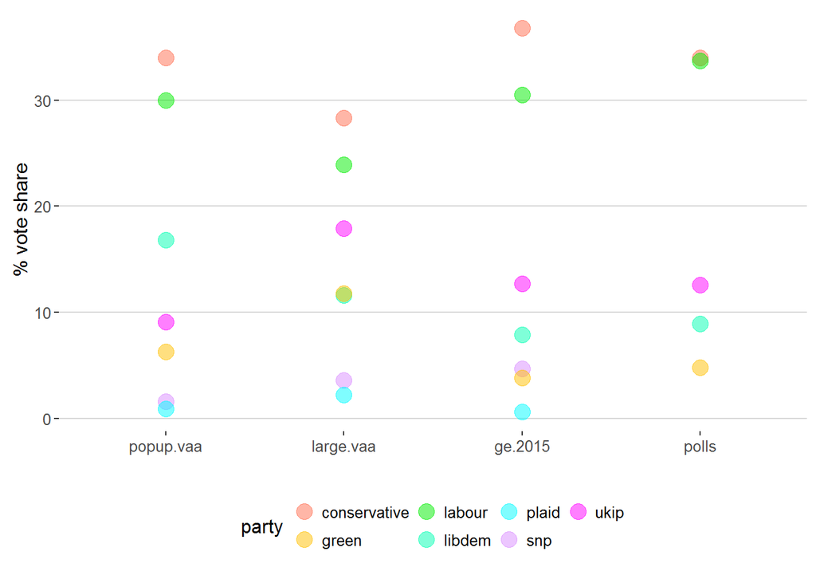

```r
ge.2015 = c(36.8,30.5,12.7,7.9,4.7,3.8,0.6) # source: http://www.bbc.com/news/election/2015/results
polls =   c(34.0,33.7,12.6,8.9,NA ,4.8,NA) # source: http://www.theguardian.com/politics/ng-interactive/2015/feb/27/guardian-poll-projection)

results <- data.frame(cbind(popup.vaa = round(100*popup.vaa,1), large.vaa = round(100*large.vaa,1),ge.2015,polls))

results$party <- c("conservative","labour","ukip","libdem","snp","green","plaid")
results.m <- melt(results)

library(ggplot2)
library(ggthemes)

g0 <- ggplot(results.m,aes(variable,value))+
  geom_point(alpha=0.5,aes(color=party),size=4.5)+
  ylab("% vote share")+
  xlab("")+
  theme_hc()+
  scale_colour_hue(l=80, c=200)
g0
```